# Bellabeat_Case_Study

Ashley Hogden

2022-04-17

### Ask

Business task: Analyze FitBit user data from April to May 2016 to identify trends in smart device usage, apply it to Bellabeat’s customers, and influence their marketing strategy.

What are some trends in smart device usage?

How can these trends apply to Bellabeat customers?

How can these trends help influence Bellabeat marketing strategy?

### Prepare data

To begin, I needed to install and load the following packages: tidyverse, dplyr, and lubridate.

I also uploaded each table from the dataset in CSV format to the R Studio Environment.

```r
activity <- read.csv("~/Downloads/Fitabase Data 4.12.16-5.12.16/dailyActivity_merged.csv")
calories <- read.csv("~/Downloads/Fitabase Data 4.12.16-5.12.16/hourlyCalories_merged.csv")
calories_minutesWide <- read.csv("~/Downloads/Fitabase Data 4.12.16-5.12.16/minuteCaloriesWide_merged.csv")
calories_minutesNarrow <- read.csv("~/Downloads/Fitabase Data 4.12.16-5.12.16/minuteCaloriesNarrow_merged.csv")
calories_daily <- read.csv("~/Downloads/Fitabase Data 4.12.16-5.12.16/dailyCalories_merged.csv")
heartrate_seconds <- read.csv("~/Downloads/Fitabase Data 4.12.16-5.12.16/heartrate_seconds_merged.csv")
intensities <- read.csv("~/Downloads/Fitabase Data 4.12.16-5.12.16/hourlyIntensities_merged.csv")
intensities_minutesWide <- read.csv("~/Downloads/Fitabase Data 4.12.16-5.12.16/minuteIntensitiesWide_merged.csv")
intensities_minutesNarrow <- read.csv("~/Downloads/Fitabase Data 4.12.16-5.12.16/minuteIntensitiesNarrow_merged.csv")
intensities_daily <- read.csv("~/Downloads/Fitabase Data 4.12.16-5.12.16/dailyIntensities_merged.csv")
METs_minutesNarrow <- read.csv("~/Downloads/Fitabase Data 4.12.16-5.12.16/minuteMETsNarrow_merged.csv")
sleep <- read.csv("~/Downloads/Fitabase Data 4.12.16-5.12.16/sleepDay_merged.csv")
sleep_minutes <- read.csv("~/Downloads/Fitabase Data 4.12.16-5.12.16/minuteSleep_merged.csv")
steps <- read.csv("~/Downloads/Fitabase Data 4.12.16-5.12.16/hourlySteps_merged.csv")
steps_minutesWide <- read.csv("~/Downloads/Fitabase Data 4.12.16-5.12.16/minuteStepsWide_merged.csv")
steps_minutesNarrow <- read.csv("~/Downloads/Fitabase Data 4.12.16-5.12.16/minuteStepsNarrow_merged.csv")
steps_daily <- read.csv("~/Downloads/Fitabase Data 4.12.16-5.12.16/dailySteps_merged.csv")
weight <- read.csv("~/Downloads/Fitabase Data 4.12.16-5.12.16/weightLogInfo_merged.csv")
```

Then, I took a quick glimpse of the each table to see the kind of data points I would be working with.

```r
head(activity)
```

```
##           Id ActivityDate TotalSteps TotalDistance TrackerDistance
## 1 1503960366    4/12/2016      13162          8.50            8.50
## 2 1503960366    4/13/2016      10735          6.97            6.97
## 3 1503960366    4/14/2016      10460          6.74            6.74
## 4 1503960366    4/15/2016       9762          6.28            6.28
## 5 1503960366    4/16/2016      12669          8.16            8.16
## 6 1503960366    4/17/2016       9705          6.48            6.48
##   LoggedActivitiesDistance VeryActiveDistance ModeratelyActiveDistance
## 1                        0               1.88                     0.55
## 2                        0               1.57                     0.69
## 3                        0               2.44                     0.40
## 4                        0               2.14                     1.26
## 5                        0               2.71                     0.41
## 6                        0               3.19                     0.78
##   LightActiveDistance SedentaryActiveDistance VeryActiveMinutes
## 1                6.06                       0                25
## 2                4.71                       0                21
## 3                3.91                       0                30
## 4                2.83                       0                29
## 5                5.04                       0                36
## 6                2.51                       0                38
##   FairlyActiveMinutes LightlyActiveMinutes SedentaryMinutes Calories
## 1                  13                  328              728     1985
## 2                  19                  217              776     1797
## 3                  11                  181             1218     1776
## 4                  34                  209              726     1745
## 5                  10                  221              773     1863
## 6                  20                  164              539     1728
```

```r
head(weight)
```

```
##           Id                  Date WeightKg WeightPounds Fat   BMI
## 1 1503960366  5/2/2016 11:59:59 PM     52.6     115.9631  22 22.65
## 2 1503960366  5/3/2016 11:59:59 PM     52.6     115.9631  NA 22.65
## 3 1927972279  4/13/2016 1:08:52 AM    133.5     294.3171  NA 47.54
## 4 2873212765 4/21/2016 11:59:59 PM     56.7     125.0021  NA 21.45
## 5 2873212765 5/12/2016 11:59:59 PM     57.3     126.3249  NA 21.69
## 6 4319703577 4/17/2016 11:59:59 PM     72.4     159.6147  25 27.45
##   IsManualReport        LogId
## 1           True 1.462234e+12
## 2           True 1.462320e+12
## 3          False 1.460510e+12
## 4           True 1.461283e+12
## 5           True 1.463098e+12
## 6           True 1.460938e+12
```

```r
head(calories)
```

```
##           Id          ActivityHour Calories
## 1 1503960366 4/12/2016 12:00:00 AM       81
## 2 1503960366  4/12/2016 1:00:00 AM       61
## 3 1503960366  4/12/2016 2:00:00 AM       59
## 4 1503960366  4/12/2016 3:00:00 AM       47
## 5 1503960366  4/12/2016 4:00:00 AM       48
## 6 1503960366  4/12/2016 5:00:00 AM       48
```

```r
head(calories_minutesWide)
```

```
##           Id          ActivityHour Calories00 Calories01 Calories02 Calories03
## 1 1503960366 4/13/2016 12:00:00 AM     1.8876     2.2022     0.9438     0.9438
## 2 1503960366  4/13/2016 1:00:00 AM     0.7865     0.7865     0.7865     0.7865
## 3 1503960366  4/13/2016 2:00:00 AM     0.7865     0.7865     0.7865     0.7865
## 4 1503960366  4/13/2016 3:00:00 AM     0.7865     0.7865     0.7865     0.7865
## 5 1503960366  4/13/2016 4:00:00 AM     0.7865     0.7865     0.7865     0.7865
## 6 1503960366  4/13/2016 5:00:00 AM     0.7865     0.7865     0.7865     0.7865
##   Calories04 Calories05 Calories06 Calories07 Calories08 Calories09 Calories10
## 1     0.9438     2.0449     0.9438     2.2022     0.9438     0.7865     0.9438
## 2     0.9438     0.9438     0.9438     0.7865     0.9438     0.7865     0.9438
## 3     0.7865     0.7865     0.7865     0.7865     0.7865     0.7865     0.7865
## 4     0.7865     0.7865     0.7865     0.7865     0.7865     0.7865     0.7865
## 5     0.7865     0.7865     0.7865     0.7865     0.7865     0.7865     0.7865
## 6     0.7865     0.7865     0.7865     0.7865     0.7865     0.7865     0.7865
##   Calories11 Calories12 Calories13 Calories14 Calories15 Calories16 Calories17
```

[output cut: 48 more lines]

```r
head(calories_minutesNarrow)
```

```
##           Id        ActivityMinute Calories
## 1 1503960366 4/12/2016 12:00:00 AM   0.7865
## 2 1503960366 4/12/2016 12:01:00 AM   0.7865
## 3 1503960366 4/12/2016 12:02:00 AM   0.7865
## 4 1503960366 4/12/2016 12:03:00 AM   0.7865
## 5 1503960366 4/12/2016 12:04:00 AM   0.7865
## 6 1503960366 4/12/2016 12:05:00 AM   0.9438
```

```r
head(calories_daily)
```

```
##           Id ActivityDay Calories
## 1 1503960366   4/12/2016     1985
## 2 1503960366   4/13/2016     1797
## 3 1503960366   4/14/2016     1776
## 4 1503960366   4/15/2016     1745
## 5 1503960366   4/16/2016     1863
## 6 1503960366   4/17/2016     1728
```

```r
head(heartrate_seconds)
```

```
##           Id                 Time Value
## 1 2022484408 4/12/2016 7:21:00 AM    97
## 2 2022484408 4/12/2016 7:21:05 AM   102
## 3 2022484408 4/12/2016 7:21:10 AM   105
## 4 2022484408 4/12/2016 7:21:20 AM   103
## 5 2022484408 4/12/2016 7:21:25 AM   101
## 6 2022484408 4/12/2016 7:22:05 AM    95
```

```r
head(intensities)
```

```
##           Id          ActivityHour TotalIntensity AverageIntensity
## 1 1503960366 4/12/2016 12:00:00 AM             20         0.333333
## 2 1503960366  4/12/2016 1:00:00 AM              8         0.133333
## 3 1503960366  4/12/2016 2:00:00 AM              7         0.116667
## 4 1503960366  4/12/2016 3:00:00 AM              0         0.000000
## 5 1503960366  4/12/2016 4:00:00 AM              0         0.000000
## 6 1503960366  4/12/2016 5:00:00 AM              0         0.000000
```

```r
head(intensities_minutesWide)
```

```
##           Id          ActivityHour Intensity00 Intensity01 Intensity02
## 1 1503960366 4/13/2016 12:00:00 AM           1           1           0
## 2 1503960366  4/13/2016 1:00:00 AM           0           0           0
## 3 1503960366  4/13/2016 2:00:00 AM           0           0           0
## 4 1503960366  4/13/2016 3:00:00 AM           0           0           0
## 5 1503960366  4/13/2016 4:00:00 AM           0           0           0
## 6 1503960366  4/13/2016 5:00:00 AM           0           0           0
##   Intensity03 Intensity04 Intensity05 Intensity06 Intensity07 Intensity08
## 1           0           0           1           0           1           0
## 2           0           0           0           0           0           0
## 3           0           0           0           0           0           0
## 4           0           0           0           0           0           0
## 5           0           0           0           0           0           0
## 6           0           0           0           0           0           0
##   Intensity09 Intensity10 Intensity11 Intensity12 Intensity13 Intensity14
```

[output cut: 62 more lines]

```r
head(intensities_minutesNarrow)
```

```
##           Id        ActivityMinute Intensity
## 1 1503960366 4/12/2016 12:00:00 AM         0
## 2 1503960366 4/12/2016 12:01:00 AM         0
## 3 1503960366 4/12/2016 12:02:00 AM         0
## 4 1503960366 4/12/2016 12:03:00 AM         0
## 5 1503960366 4/12/2016 12:04:00 AM         0
## 6 1503960366 4/12/2016 12:05:00 AM         0
```

```r
head(intensities_daily)
```

```
##           Id ActivityDay SedentaryMinutes LightlyActiveMinutes
## 1 1503960366   4/12/2016              728                  328
## 2 1503960366   4/13/2016              776                  217
## 3 1503960366   4/14/2016             1218                  181
## 4 1503960366   4/15/2016              726                  209
## 5 1503960366   4/16/2016              773                  221
## 6 1503960366   4/17/2016              539                  164
##   FairlyActiveMinutes VeryActiveMinutes SedentaryActiveDistance
## 1                  13                25                       0
## 2                  19                21                       0
## 3                  11                30                       0
## 4                  34                29                       0
## 5                  10                36                       0
## 6                  20                38                       0
##   LightActiveDistance ModeratelyActiveDistance VeryActiveDistance
## 1                6.06                     0.55               1.88
## 2                4.71                     0.69               1.57
## 3                3.91                     0.40               2.44
## 4                2.83                     1.26               2.14
## 5                5.04                     0.41               2.71
## 6                2.51                     0.78               3.19
```

```r
head(METs_minutesNarrow)
```

```
##           Id        ActivityMinute METs
## 1 1503960366 4/12/2016 12:00:00 AM   10
## 2 1503960366 4/12/2016 12:01:00 AM   10
## 3 1503960366 4/12/2016 12:02:00 AM   10
## 4 1503960366 4/12/2016 12:03:00 AM   10
## 5 1503960366 4/12/2016 12:04:00 AM   10
## 6 1503960366 4/12/2016 12:05:00 AM   12
```

```r
head(sleep)
```

```
##           Id              SleepDay TotalSleepRecords TotalMinutesAsleep
## 1 1503960366 4/12/2016 12:00:00 AM                 1                327
## 2 1503960366 4/13/2016 12:00:00 AM                 2                384
## 3 1503960366 4/15/2016 12:00:00 AM                 1                412
## 4 1503960366 4/16/2016 12:00:00 AM                 2                340
## 5 1503960366 4/17/2016 12:00:00 AM                 1                700
## 6 1503960366 4/19/2016 12:00:00 AM                 1                304
##   TotalTimeInBed
## 1            346
## 2            407
## 3            442
## 4            367
## 5            712
## 6            320
```

```r
head(sleep_minutes)
```

```
##           Id                 date value       logId
## 1 1503960366 4/12/2016 2:47:30 AM     3 11380564589
## 2 1503960366 4/12/2016 2:48:30 AM     2 11380564589
## 3 1503960366 4/12/2016 2:49:30 AM     1 11380564589
## 4 1503960366 4/12/2016 2:50:30 AM     1 11380564589
## 5 1503960366 4/12/2016 2:51:30 AM     1 11380564589
## 6 1503960366 4/12/2016 2:52:30 AM     1 11380564589
```

```r
head(steps)
```

```
##           Id          ActivityHour StepTotal
## 1 1503960366 4/12/2016 12:00:00 AM       373
## 2 1503960366  4/12/2016 1:00:00 AM       160
## 3 1503960366  4/12/2016 2:00:00 AM       151
## 4 1503960366  4/12/2016 3:00:00 AM         0
## 5 1503960366  4/12/2016 4:00:00 AM         0
## 6 1503960366  4/12/2016 5:00:00 AM         0
```

```r
head(steps_minutesWide)
```

```
##           Id          ActivityHour Steps00 Steps01 Steps02 Steps03 Steps04
## 1 1503960366 4/13/2016 12:00:00 AM       4      16       0       0       0
## 2 1503960366  4/13/2016 1:00:00 AM       0       0       0       0       0
## 3 1503960366  4/13/2016 2:00:00 AM       0       0       0       0       0
## 4 1503960366  4/13/2016 3:00:00 AM       0       0       0       0       0
## 5 1503960366  4/13/2016 4:00:00 AM       0       0       0       0       0
## 6 1503960366  4/13/2016 5:00:00 AM       0       0       0       0       0
##   Steps05 Steps06 Steps07 Steps08 Steps09 Steps10 Steps11 Steps12 Steps13
## 1       9       0      17       0       0       0       0       0       0
## 2       0       0       0       0       0       0       0       0       0
## 3       0       0       0       0       0       0       0       0       0
## 4       0       0       0       0       0       0      10       0       0
## 5       0       0       0       0       0       0       0       0       0
## 6       0       0       0       0       0       0       0       0       0
##   Steps14 Steps15 Steps16 Steps17 Steps18 Steps19 Steps20 Steps21 Steps22
```

[output cut: 41 more lines]

```r
head(steps_minutesNarrow)
```

```
##           Id        ActivityMinute Steps
## 1 1503960366 4/12/2016 12:00:00 AM     0
## 2 1503960366 4/12/2016 12:01:00 AM     0
## 3 1503960366 4/12/2016 12:02:00 AM     0
## 4 1503960366 4/12/2016 12:03:00 AM     0
## 5 1503960366 4/12/2016 12:04:00 AM     0
## 6 1503960366 4/12/2016 12:05:00 AM     0
```

```r
head(steps_daily)
```

```
##           Id ActivityDay StepTotal
## 1 1503960366   4/12/2016     13162
## 2 1503960366   4/13/2016     10735
## 3 1503960366   4/14/2016     10460
## 4 1503960366   4/15/2016      9762
## 5 1503960366   4/16/2016     12669
## 6 1503960366   4/17/2016      9705
```

### Process data

##### Remove duplicates

I utilized the unique() function to remove any duplicates from each table.

```r
activity <- unique(activity)
calories <- unique(calories)
calories_daily <- unique(calories_daily)
calories_minutesNarrow <- unique(calories_minutesNarrow)
calories_minutesWide <- unique(calories_minutesWide)
heartrate_seconds <- unique(heartrate_seconds)
intensities <- unique(intensities)
intensities_daily <- unique(intensities_daily)
intensities_minutesNarrow <- unique(intensities_minutesNarrow)
intensities_minutesWide <- unique(intensities_minutesWide)
METs_minutesNarrow <- unique(METs_minutesNarrow)
steps <- unique(steps)
steps_daily <- unique(steps_daily)
steps_minutesNarrow <- unique(steps_minutesNarrow)
steps_minutesWide <- unique(steps_minutesWide)
weight <- unique(weight)
```

##### Removing unnecessary columns

After utilizing the head() function earlier, I noticed that the Fat column in the weight table had only two values logged, while the rest were NAs. As a result, I removed this column because the lack of sufficient data rendered it useless.

```r
weight <- subset(weight, select = -c(Fat))
```

##### Structure

Next, I took a look at the structure of each table to determine if I needed to change the data type for any of the columns.

```r
str(activity)
```

```
## 'data.frame':    940 obs. of  15 variables:
##  $ Id                      : num  1.5e+09 1.5e+09 1.5e+09 1.5e+09 1.5e+09 ...
##  $ ActivityDate            : chr  "4/12/2016" "4/13/2016" "4/14/2016" "4/15/2016" ...
##  $ TotalSteps              : int  13162 10735 10460 9762 12669 9705 13019 15506 10544 9819 ...
##  $ TotalDistance           : num  8.5 6.97 6.74 6.28 8.16 ...
##  $ TrackerDistance         : num  8.5 6.97 6.74 6.28 8.16 ...
##  $ LoggedActivitiesDistance: num  0 0 0 0 0 0 0 0 0 0 ...
##  $ VeryActiveDistance      : num  1.88 1.57 2.44 2.14 2.71 ...
##  $ ModeratelyActiveDistance: num  0.55 0.69 0.4 1.26 0.41 ...
##  $ LightActiveDistance     : num  6.06 4.71 3.91 2.83 5.04 ...
##  $ SedentaryActiveDistance : num  0 0 0 0 0 0 0 0 0 0 ...
##  $ VeryActiveMinutes       : int  25 21 30 29 36 38 42 50 28 19 ...
##  $ FairlyActiveMinutes     : int  13 19 11 34 10 20 16 31 12 8 ...
##  $ LightlyActiveMinutes    : int  328 217 181 209 221 164 233 264 205 211 ...
##  $ SedentaryMinutes        : int  728 776 1218 726 773 539 1149 775 818 838 ...
##  $ Calories                : int  1985 1797 1776 1745 1863 1728 1921 2035 1786 1775 ...
```

```r
str(calories)
```

```
## 'data.frame':    22099 obs. of  3 variables:
##  $ Id          : num  1.5e+09 1.5e+09 1.5e+09 1.5e+09 1.5e+09 ...
##  $ ActivityHour: chr  "4/12/2016 12:00:00 AM" "4/12/2016 1:00:00 AM" "4/12/2016 2:00:00 AM" "4/12/2016 3:00:00 AM" ...
##  $ Calories    : int  81 61 59 47 48 48 48 47 68 141 ...
```

```r
str(calories_minutesWide)
```

```
## 'data.frame':    21645 obs. of  62 variables:
##  $ Id          : num  1.5e+09 1.5e+09 1.5e+09 1.5e+09 1.5e+09 ...
##  $ ActivityHour: chr  "4/13/2016 12:00:00 AM" "4/13/2016 1:00:00 AM" "4/13/2016 2:00:00 AM" "4/13/2016 3:00:00 AM" ...
##  $ Calories00  : num  1.888 0.786 0.786 0.786 0.786 ...
##  $ Calories01  : num  2.202 0.786 0.786 0.786 0.786 ...
##  $ Calories02  : num  0.944 0.786 0.786 0.786 0.786 ...
##  $ Calories03  : num  0.944 0.786 0.786 0.786 0.786 ...
##  $ Calories04  : num  0.944 0.944 0.786 0.786 0.786 ...
##  $ Calories05  : num  2.045 0.944 0.786 0.786 0.786 ...
##  $ Calories06  : num  0.944 0.944 0.786 0.786 0.786 ...
##  $ Calories07  : num  2.202 0.786 0.786 0.786 0.786 ...
##  $ Calories08  : num  0.944 0.944 0.786 0.786 0.786 ...
##  $ Calories09  : num  0.786 0.786 0.786 0.786 0.786 ...
##  $ Calories10  : num  0.944 0.944 0.786 0.786 0.786 ...
##  $ Calories11  : num  0.786 0.786 0.786 2.045 0.786 ...
```

[output cut: 48 more lines]

```r
str(calories_minutesNarrow)
```

```
## 'data.frame':    1325580 obs. of  3 variables:
##  $ Id            : num  1.5e+09 1.5e+09 1.5e+09 1.5e+09 1.5e+09 ...
##  $ ActivityMinute: chr  "4/12/2016 12:00:00 AM" "4/12/2016 12:01:00 AM" "4/12/2016 12:02:00 AM" "4/12/2016 12:03:00 AM" ...
##  $ Calories      : num  0.786 0.786 0.786 0.786 0.786 ...
```

```r
str(calories_daily)
```

```
## 'data.frame':    940 obs. of  3 variables:
##  $ Id         : num  1.5e+09 1.5e+09 1.5e+09 1.5e+09 1.5e+09 ...
##  $ ActivityDay: chr  "4/12/2016" "4/13/2016" "4/14/2016" "4/15/2016" ...
##  $ Calories   : int  1985 1797 1776 1745 1863 1728 1921 2035 1786 1775 ...
```

```r
str(heartrate_seconds)
```

```
## 'data.frame':    2483658 obs. of  3 variables:
##  $ Id   : num  2.02e+09 2.02e+09 2.02e+09 2.02e+09 2.02e+09 ...
##  $ Time : chr  "4/12/2016 7:21:00 AM" "4/12/2016 7:21:05 AM" "4/12/2016 7:21:10 AM" "4/12/2016 7:21:20 AM" ...
##  $ Value: int  97 102 105 103 101 95 91 93 94 93 ...
```

```r
str(intensities)
```

```
## 'data.frame':    22099 obs. of  4 variables:
##  $ Id              : num  1.5e+09 1.5e+09 1.5e+09 1.5e+09 1.5e+09 ...
##  $ ActivityHour    : chr  "4/12/2016 12:00:00 AM" "4/12/2016 1:00:00 AM" "4/12/2016 2:00:00 AM" "4/12/2016 3:00:00 AM" ...
##  $ TotalIntensity  : int  20 8 7 0 0 0 0 0 13 30 ...
##  $ AverageIntensity: num  0.333 0.133 0.117 0 0 ...
```

```r
str(intensities_minutesWide)
```

```
## 'data.frame':    21645 obs. of  62 variables:
##  $ Id          : num  1.5e+09 1.5e+09 1.5e+09 1.5e+09 1.5e+09 ...
##  $ ActivityHour: chr  "4/13/2016 12:00:00 AM" "4/13/2016 1:00:00 AM" "4/13/2016 2:00:00 AM" "4/13/2016 3:00:00 AM" ...
##  $ Intensity00 : int  1 0 0 0 0 0 0 0 0 0 ...
##  $ Intensity01 : int  1 0 0 0 0 0 0 0 0 1 ...
##  $ Intensity02 : int  0 0 0 0 0 0 0 0 0 1 ...
##  $ Intensity03 : int  0 0 0 0 0 0 0 0 0 1 ...
##  $ Intensity04 : int  0 0 0 0 0 0 0 0 0 1 ...
##  $ Intensity05 : int  1 0 0 0 0 0 0 0 0 1 ...
##  $ Intensity06 : int  0 0 0 0 0 0 0 0 0 1 ...
##  $ Intensity07 : int  1 0 0 0 0 0 0 0 0 1 ...
##  $ Intensity08 : int  0 0 0 0 0 0 0 0 0 1 ...
##  $ Intensity09 : int  0 0 0 0 0 0 0 0 0 1 ...
##  $ Intensity10 : int  0 0 0 0 0 0 0 0 0 1 ...
##  $ Intensity11 : int  0 0 0 1 0 0 0 0 1 1 ...
```

[output cut: 48 more lines]

```r
str(intensities_minutesNarrow)
```

```
## 'data.frame':    1325580 obs. of  3 variables:
##  $ Id            : num  1.5e+09 1.5e+09 1.5e+09 1.5e+09 1.5e+09 ...
##  $ ActivityMinute: chr  "4/12/2016 12:00:00 AM" "4/12/2016 12:01:00 AM" "4/12/2016 12:02:00 AM" "4/12/2016 12:03:00 AM" ...
##  $ Intensity     : int  0 0 0 0 0 0 0 0 0 0 ...
```

```r
str(intensities_daily)
```

```
## 'data.frame':    940 obs. of  10 variables:
##  $ Id                      : num  1.5e+09 1.5e+09 1.5e+09 1.5e+09 1.5e+09 ...
##  $ ActivityDay             : chr  "4/12/2016" "4/13/2016" "4/14/2016" "4/15/2016" ...
##  $ SedentaryMinutes        : int  728 776 1218 726 773 539 1149 775 818 838 ...
##  $ LightlyActiveMinutes    : int  328 217 181 209 221 164 233 264 205 211 ...
##  $ FairlyActiveMinutes     : int  13 19 11 34 10 20 16 31 12 8 ...
##  $ VeryActiveMinutes       : int  25 21 30 29 36 38 42 50 28 19 ...
##  $ SedentaryActiveDistance : num  0 0 0 0 0 0 0 0 0 0 ...
##  $ LightActiveDistance     : num  6.06 4.71 3.91 2.83 5.04 ...
##  $ ModeratelyActiveDistance: num  0.55 0.69 0.4 1.26 0.41 ...
##  $ VeryActiveDistance      : num  1.88 1.57 2.44 2.14 2.71 ...
```

```r
str(METs_minutesNarrow)
```

```
## 'data.frame':    1325580 obs. of  3 variables:
##  $ Id            : num  1.5e+09 1.5e+09 1.5e+09 1.5e+09 1.5e+09 ...
##  $ ActivityMinute: chr  "4/12/2016 12:00:00 AM" "4/12/2016 12:01:00 AM" "4/12/2016 12:02:00 AM" "4/12/2016 12:03:00 AM" ...
##  $ METs          : int  10 10 10 10 10 12 12 12 12 12 ...
```

```r
str(sleep)
```

```
## 'data.frame':    413 obs. of  5 variables:
##  $ Id                : num  1.5e+09 1.5e+09 1.5e+09 1.5e+09 1.5e+09 ...
##  $ SleepDay          : chr  "4/12/2016 12:00:00 AM" "4/13/2016 12:00:00 AM" "4/15/2016 12:00:00 AM" "4/16/2016 12:00:00 AM" ...
##  $ TotalSleepRecords : int  1 2 1 2 1 1 1 1 1 1 ...
##  $ TotalMinutesAsleep: int  327 384 412 340 700 304 360 325 361 430 ...
##  $ TotalTimeInBed    : int  346 407 442 367 712 320 377 364 384 449 ...
```

```r
str(sleep_minutes)
```

```
## 'data.frame':    188521 obs. of  4 variables:
##  $ Id   : num  1.5e+09 1.5e+09 1.5e+09 1.5e+09 1.5e+09 ...
##  $ date : chr  "4/12/2016 2:47:30 AM" "4/12/2016 2:48:30 AM" "4/12/2016 2:49:30 AM" "4/12/2016 2:50:30 AM" ...
##  $ value: int  3 2 1 1 1 1 1 2 2 2 ...
##  $ logId: num  1.14e+10 1.14e+10 1.14e+10 1.14e+10 1.14e+10 ...
```

```r
str(steps)
```

```
## 'data.frame':    22099 obs. of  3 variables:
##  $ Id          : num  1.5e+09 1.5e+09 1.5e+09 1.5e+09 1.5e+09 ...
##  $ ActivityHour: chr  "4/12/2016 12:00:00 AM" "4/12/2016 1:00:00 AM" "4/12/2016 2:00:00 AM" "4/12/2016 3:00:00 AM" ...
##  $ StepTotal   : int  373 160 151 0 0 0 0 0 250 1864 ...
```

```r
str(steps_daily)
```

```
## 'data.frame':    940 obs. of  3 variables:
##  $ Id         : num  1.5e+09 1.5e+09 1.5e+09 1.5e+09 1.5e+09 ...
##  $ ActivityDay: chr  "4/12/2016" "4/13/2016" "4/14/2016" "4/15/2016" ...
##  $ StepTotal  : int  13162 10735 10460 9762 12669 9705 13019 15506 10544 9819 ...
```

```r
str(steps_minutesNarrow)
```

```
## 'data.frame':    1325580 obs. of  3 variables:
##  $ Id            : num  1.5e+09 1.5e+09 1.5e+09 1.5e+09 1.5e+09 ...
##  $ ActivityMinute: chr  "4/12/2016 12:00:00 AM" "4/12/2016 12:01:00 AM" "4/12/2016 12:02:00 AM" "4/12/2016 12:03:00 AM" ...
##  $ Steps         : int  0 0 0 0 0 0 0 0 0 0 ...
```

```r
str(steps_minutesWide)
```

```
## 'data.frame':    21645 obs. of  62 variables:
##  $ Id          : num  1.5e+09 1.5e+09 1.5e+09 1.5e+09 1.5e+09 ...
##  $ ActivityHour: chr  "4/13/2016 12:00:00 AM" "4/13/2016 1:00:00 AM" "4/13/2016 2:00:00 AM" "4/13/2016 3:00:00 AM" ...
##  $ Steps00     : int  4 0 0 0 0 0 0 0 0 0 ...
##  $ Steps01     : int  16 0 0 0 0 0 0 0 0 14 ...
##  $ Steps02     : int  0 0 0 0 0 0 0 0 0 10 ...
##  $ Steps03     : int  0 0 0 0 0 0 0 0 0 31 ...
##  $ Steps04     : int  0 0 0 0 0 0 0 0 0 37 ...
##  $ Steps05     : int  9 0 0 0 0 0 0 0 0 17 ...
##  $ Steps06     : int  0 0 0 0 0 0 0 0 0 25 ...
##  $ Steps07     : int  17 0 0 0 0 0 0 0 0 12 ...
##  $ Steps08     : int  0 0 0 0 0 0 0 0 0 6 ...
##  $ Steps09     : int  0 0 0 0 0 0 0 0 0 30 ...
##  $ Steps10     : int  0 0 0 0 0 0 0 0 0 7 ...
##  $ Steps11     : int  0 0 0 10 0 0 0 0 6 109 ...
```

[output cut: 48 more lines]

```r
str(weight)
```

```
## 'data.frame':    67 obs. of  7 variables:
##  $ Id            : num  1.50e+09 1.50e+09 1.93e+09 2.87e+09 2.87e+09 ...
##  $ Date          : chr  "5/2/2016 11:59:59 PM" "5/3/2016 11:59:59 PM" "4/13/2016 1:08:52 AM" "4/21/2016 11:59:59 PM" ...
##  $ WeightKg      : num  52.6 52.6 133.5 56.7 57.3 ...
##  $ WeightPounds  : num  116 116 294 125 126 ...
##  $ BMI           : num  22.6 22.6 47.5 21.5 21.7 ...
##  $ IsManualReport: chr  "True" "True" "False" "True" ...
##  $ LogId         : num  1.46e+12 1.46e+12 1.46e+12 1.46e+12 1.46e+12 ...
```

##### Converting data types

I noticed that all of the dates in each table were set as a character data type, so I decided to convert these from the character type to POSIXct format for the sake of uniformity. This requires the lubridate package.

```r
activity$ActivityDate <- as.POSIXct(activity$ActivityDate, format = "%m/%d/%Y")
calories$ActivityHour <- as.POSIXct(calories$ActivityHour, format = "%m/%d/%Y %H:%M:%S")
calories_daily$ActivityDay <- as.POSIXct(calories_daily$ActivityDay, format = "%m/%d/%Y")
calories_minutesNarrow$ActivityMinute <- as.POSIXct(calories_minutesNarrow$ActivityMinute, format = "%m/%d/%Y %H:%M:%S")
calories_minutesWide$ActivityHour <- as.POSIXct(calories_minutesWide$ActivityHour, format = "%m/%d/%Y %H:%M:%S")
heartrate_seconds$Time <- as.POSIXct(heartrate_seconds$Time, format = "%m/%d/%Y")
intensities$ActivityHour <- as.POSIXct(intensities$ActivityHour, format = "%m/%d/%Y %H:%M:%S")
intensities_daily$ActivityDay <- as.POSIXct(intensities_daily$ActivityDay, format = "%m/%d/%Y")
intensities_minutesNarrow$ActivityMinute <- as.POSIXct(intensities_minutesNarrow$ActivityMinute, format = "%m/%d/%Y %H:%M:%S")
intensities_minutesWide$ActivityHour <- as.POSIXct(intensities_minutesWide$ActivityHour, format = "%m/%d/%Y %H:%M:%S")
METs_minutesNarrow$ActivityMinute <- as.POSIXct(METs_minutesNarrow$ActivityMinute, format = "%m/%d/%Y %H:%M:%S")
sleep$SleepDay <- as.POSIXct(sleep$SleepDay, format = "%m/%d/%Y")
sleep_minutes$date <- as.POSIXct(sleep_minutes$date, format = "%m/%d/%Y %H:%M:%S")
steps$ActivityHour <- as.POSIXct(steps$ActivityHour, format = "%m/%d/%Y %H:%M:%S")
steps_daily$ActivityDay <- as.POSIXct(steps_daily$ActivityDay, format = "%m/%d/%Y")
steps_minutesNarrow$ActivityMinute <- as.POSIXct(steps_minutesNarrow$ActivityMinute, format = "%m/%d/%Y %H:%M:%S")
steps_minutesWide$ActivityHour <- as.POSIXct(steps_minutesWide$ActivityHour, format = "%m/%d/%Y %H:%M:%S")
weight$Date <- as.POSIXct(weight$Date, format = "%m/%d/%Y")
```

I also found that the weight table had a column of boolean data points that were listed as characters. Because of this, I converted the data types from character to logical.

```r
weight <- weight %>%
  mutate_if(is.character, as.logical)
```

I also wanted to convert the data type for all of the Ids in each table from number to character so visualizations would show a distinct variable, rather than a numerical range.

```r
activity$Id <- as.character(activity$Id)
calories$Id <- as.character(calories$Id)
calories_daily$Id <- as.character(calories_daily$Id)
calories_minutesNarrow$Id <- as.character(calories_minutesNarrow$Id)
calories_minutesWide$Id <- as.character(calories_minutesWide$Id)
heartrate_seconds$Id <- as.character(heartrate_seconds$Id)
intensities$Id <- as.character(intensities$Id)
intensities_daily$Id <- as.character(intensities_daily$Id)
intensities_minutesNarrow$Id <- as.character(intensities_minutesNarrow$Id)
intensities_minutesWide$Id <- as.character(intensities_minutesWide$Id)
METs_minutesNarrow$Id <- as.character(METs_minutesNarrow$Id)
sleep$Id <- as.character(sleep$Id)
sleep_minutes$Id <- as.character(sleep_minutes$Id)
steps$Id <- as.character(steps$Id)
steps_daily$Id <- as.character(steps_daily$Id)
steps_minutesNarrow$Id <- as.character(steps_minutesNarrow$Id)
steps_minutesWide$Id <- as.character(steps_minutesWide$Id)
weight$Id <- as.character(weight$Id)
weight$LogId <- as.character(weight$LogId)
```

Lastly, I renamed corresponding columns in a dataframe so that they would indicate a standardized measurement (e.g. ModeratelyActiveDistance was used in place of FairlyActiveDistance). This will make it easier for me to write code when visualizing or merging datasets.

```r
names(activity)[names(activity) == 'ActivityDate'] <- 'Date'
names(activity)[names(activity) == 'FairlyActiveMinutes'] <- 'ModeratelyActiveMinutes'
names(activity)[names(activity) == 'LightActiveDistance'] <- 'LightlyActiveDistance'
names(activity)[names(activity) == 'SedentaryMinutes']  <- 'SedentaryActiveMinutes'

names(calories_daily)[names(calories_daily) == 'ActivityDay'] <- 'Date'

names(heartrate_seconds)[names(heartrate_seconds) == 'Time'] <- 'Date'

names(intensities_daily)[names(intensities_daily) == 'ActivityDay'] <- 'Date'
names(intensities_daily)[names(intensities_daily) == 'FairlyActiveMinutes'] <- 'ModeratelyActiveMinutes'
names(intensities_daily)[names(intensities_daily) == 'LightActiveDistance'] <- 'LightlyActiveDistance'
names(intensities_daily)[names(intensities_daily) == 'SedentaryMinutes'] <- 'SedentaryActiveMinutes'

names(sleep)[names(sleep) == 'SleepDay'] <- 'Date'

names(steps_daily)[names(steps_daily) == 'ActivityDay'] <- 'Date'
names(steps_daily)[names(steps_daily) == 'StepTotal'] <- 'TotalSteps'
```

##### Merging datasets

My first goal was to join the tables that contained daily data points so I could see if there were any trends throughout users’ day-to-day lives.

```r
DailyData1 <- merge(x = activity, y = calories_daily, by = c("Id", "Date", "Calories"))
DailyData2 <- merge(x = intensities_daily, y = steps_daily, by = c("Id", "Date"))
DailyData <- merge(x = DailyData1, y = DailyData2, by = c("Id", "Date", "SedentaryActiveMinutes", "LightlyActiveMinutes", "ModeratelyActiveMinutes", "VeryActiveMinutes", "SedentaryActiveDistance", "VeryActiveDistance", "ModeratelyActiveDistance", "LightlyActiveDistance", "TotalSteps"))
```

##### Cleaning the daily data

Then I had to repeat the cleaning process once again. I began this by removing any duplicate values.

```r
DailyData <- unique(DailyData)
```

Once duplicates were removed, I wanted to determine if there were any users who were infrequent contributors to the data that they could qualify as outliers. The plot below shows that one Id only logged 4 times.

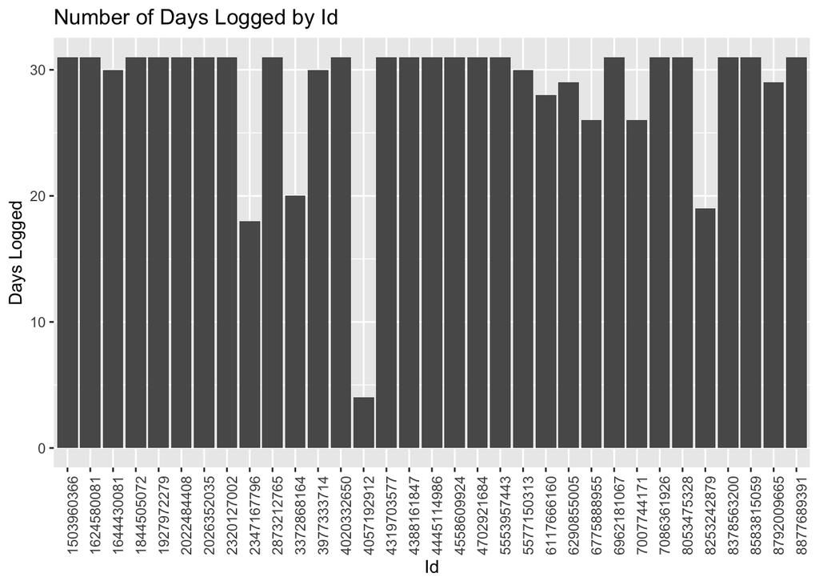

```r
ggplot(data = DailyData, aes(x = Id)) + geom_bar() + labs(title = "Number of Days Logged by Id", y = "Days Logged") + theme(axis.text.x = element_text(angle=90))
```

I executed the code chunk below which removed that outlier Id from the dataset.

```r
DailyData <- DailyData %>% filter(!grepl("4057192912", Id))
```

Finally, I mutated the DailyData table to create a new table with distinct IDs and means for all other variables.

```r
DailyDataIdAvg <- DailyData %>%
  group_by(Id) %>%
  summarize(
    Id = unique(Id),
    DatesLogged = sum(Date > 0, na.rm = TRUE),
    Steps = mean(TotalSteps),
    Distance = mean(TotalDistance),
    TrackerDistance = mean(TrackerDistance),
    VeryActiveDistance = mean(VeryActiveDistance),
    ModeratelyActiveDistance = mean(ModeratelyActiveDistance),
    LightlyActiveDistance = mean(LightlyActiveDistance),
    SedentaryActiveDistance = mean(SedentaryActiveDistance),
    VeryActiveMinutes = mean(VeryActiveMinutes),
    ModeratelyActiveMinutes = mean(ModeratelyActiveMinutes),
    LightlyActiveMinutes = mean(LightlyActiveMinutes),
    SedentaryActiveMinutes = mean(SedentaryActiveMinutes),
    Calories = mean(Calories),
  )
```

##### Rating each type of activity level for each Id

In order to really examine the activity levels for each Id, I aimed to rate each user’s frequency of time spent at each activity level. To do this, I started by finding the minimum, maximum, and mean for data in the VeryActiveMinutes column.

```r
min(DailyDataIdAvg$VeryActiveMinutes)
```

```
## [1] 0.09677419
```

```r
max(DailyDataIdAvg$VeryActiveMinutes)
```

```
## [1] 87.33333
```

```r
VeryMean <- mean(DailyDataIdAvg$VeryActiveMinutes)
```

I then took the mean of the upper half of the data in this column. This will give me a threshold for above average time spent in this particular activity level.

```r
VeryAboveAvg <- mean(data.matrix(DailyDataIdAvg[DailyDataIdAvg$VeryActiveMinutes >= VeryMean, "VeryActiveMinutes"]))
```

I repeated this step with the lower half of the data in this column. This will give me a threshold for the below average time spent in this particular activity level.

```r
VeryBelowAvg <- mean(data.matrix(DailyDataIdAvg[DailyDataIdAvg$VeryActiveMinutes <= VeryMean, "VeryActiveMinutes"]))
```

Finally, I created a new column with descriptive variables that placed each Id in one of the following categories. Numbers were used in front of each variable for so my ggplot2 visualizations would correctly order each variable from low to high, instead of alphabetical order.

```r
DailyDataIdAvg$VeryActiveStatus[DailyDataIdAvg$VeryActiveMinutes >= VeryAboveAvg] <- "4 High"
DailyDataIdAvg$VeryActiveStatus[DailyDataIdAvg$VeryActiveMinutes <= VeryAboveAvg] <- "3 MeanHigh"
DailyDataIdAvg$VeryActiveStatus[DailyDataIdAvg$VeryActiveMinutes <= VeryMean] <- "2 MeanLow"
DailyDataIdAvg$VeryActiveStatus[DailyDataIdAvg$VeryActiveMinutes <= VeryBelowAvg] <- "1 Low"
```

Then I repeated these steps for time spent at all other activity types.

Moderately Active:

```r
min(DailyDataIdAvg$ModeratelyActiveMinutes)
```

```
## [1] 0.2580645
```

```r
max(DailyDataIdAvg$ModeratelyActiveMinutes)
```

```
## [1] 61.26667
```

```r
ModeratelyMean <- mean(DailyDataIdAvg$ModeratelyActiveMinutes)

ModeratelyAboveAvg <- mean(data.matrix(DailyDataIdAvg[DailyDataIdAvg$ModeratelyActiveMinutes >= ModeratelyMean, "ModeratelyActiveMinutes"]))
ModeratelyBelowAvg <- mean(data.matrix(DailyDataIdAvg[DailyDataIdAvg$ModeratelyActiveMinutes <= ModeratelyMean, "ModeratelyActiveMinutes"]))

DailyDataIdAvg$ModeratelyActiveStatus[DailyDataIdAvg$ModeratelyActiveMinutes >= ModeratelyAboveAvg] <- "4 High"
DailyDataIdAvg$ModeratelyActiveStatus[DailyDataIdAvg$ModeratelyActiveMinutes <= ModeratelyAboveAvg] <- "3 MeanHigh"
DailyDataIdAvg$ModeratelyActiveStatus[DailyDataIdAvg$ModeratelyActiveMinutes <= ModeratelyMean] <- "2 MeanLow"
DailyDataIdAvg$ModeratelyActiveStatus[DailyDataIdAvg$ModeratelyActiveMinutes <= ModeratelyBelowAvg] <- "1 Low"
```

Lightly Active:

```r
min(DailyDataIdAvg$LightlyActiveMinutes)
```

```
## [1] 38.58065
```

```r
max(DailyDataIdAvg$LightlyActiveMinutes)
```

```
## [1] 327.9
```

```r
LightlyMean <- mean(DailyDataIdAvg$LightlyActiveMinutes)

LightlyAboveAvg <- mean(data.matrix(DailyDataIdAvg[DailyDataIdAvg$LightlyActiveMinutes >= LightlyMean, "LightlyActiveMinutes"]))
LightlyBelowAvg <- mean(data.matrix(DailyDataIdAvg[DailyDataIdAvg$LightlyActiveMinutes <= LightlyMean, "LightlyActiveMinutes"]))

DailyDataIdAvg$LightlyActiveStatus[DailyDataIdAvg$LightlyActiveMinutes >= LightlyAboveAvg] <- "4 High"
DailyDataIdAvg$LightlyActiveStatus[DailyDataIdAvg$LightlyActiveMinutes <= LightlyAboveAvg] <- "3 MeanHigh"
DailyDataIdAvg$LightlyActiveStatus[DailyDataIdAvg$LightlyActiveMinutes <= LightlyMean] <- "2 MeanLow"
DailyDataIdAvg$LightlyActiveStatus[DailyDataIdAvg$LightlyActiveMinutes <= LightlyBelowAvg] <- "1 Low"
```

Sedentary:

```r
min(DailyDataIdAvg$SedentaryActiveMinutes)
```

```
## [1] 662.3226
```

```r
max(DailyDataIdAvg$SedentaryActiveMinutes)
```

```
## [1] 1317.419
```

```r
SedentaryMean <- mean(DailyDataIdAvg$SedentaryActiveMinutes)

SedentaryAboveAvg <- mean(data.matrix(DailyDataIdAvg[DailyDataIdAvg$SedentaryActiveMinutes >= SedentaryMean, "SedentaryActiveMinutes"]))
SedentaryBelowAvg <- mean(data.matrix(DailyDataIdAvg[DailyDataIdAvg$SedentaryActiveMinutes <= SedentaryMean, "SedentaryActiveMinutes"]))

DailyDataIdAvg$SedentaryActiveStatus[DailyDataIdAvg$SedentaryActiveMinutes >= SedentaryAboveAvg] <- "4 High"
DailyDataIdAvg$SedentaryActiveStatus[DailyDataIdAvg$SedentaryActiveMinutes <= SedentaryAboveAvg] <- "3 MeanHigh"
DailyDataIdAvg$SedentaryActiveStatus[DailyDataIdAvg$SedentaryActiveMinutes <= SedentaryMean] <- "2 MeanLow"
DailyDataIdAvg$SedentaryActiveStatus[DailyDataIdAvg$SedentaryActiveMinutes <= SedentaryBelowAvg] <- "1 Low"
```

Next, I added the ActivityStatus column for each physicality level to all the Ids in the bigger table.

```r
DailyData$VeryActiveStatus <- DailyDataIdAvg$VeryActiveStatus[match(DailyData$Id, DailyDataIdAvg$Id)]
DailyData$ModeratelyActiveStatus <- DailyDataIdAvg$ModeratelyActiveStatus[match(DailyData$Id, DailyDataIdAvg$Id)]
DailyData$LightlyActiveStatus <- DailyDataIdAvg$LightlyActiveStatus[match(DailyData$Id, DailyDataIdAvg$Id)]
DailyData$SedentaryActiveStatus <- DailyDataIdAvg$SedentaryActiveStatus[match(DailyData$Id, DailyDataIdAvg$Id)]

DailyData$VeryActiveStatus <- DailyDataIdAvg$VeryActiveStatus[match(DailyData$Id, DailyDataIdAvg$Id)]
DailyData$ModeratelyActiveStatus <- DailyDataIdAvg$ModeratelyActiveStatus[match(DailyData$Id, DailyDataIdAvg$Id)]
DailyData$LightlyActiveStatus <- DailyDataIdAvg$LightlyActiveStatus[match(DailyData$Id, DailyDataIdAvg$Id)]
DailyData$SedentaryActiveStatus <- DailyDataIdAvg$SedentaryActiveStatus[match(DailyData$Id, DailyDataIdAvg$Id)]
```

I also combined the sleep table with the DailyData table to see if there were any identifiable trends in activity level and sleep.

```r
dailydata_sleepall <- merge(x = sleep, y = DailyData, by = c("Id", "Date"), all = TRUE)
```

I removed the NAs that appeared from merging the sleep table with the DailyData table, as some users did not log their sleep consistently.

```r
dailydata_sleepall <- dailydata_sleepall %>% drop_na()
```

After that, I determined the overall activity status for each user by taking the mean of the Total Average Steps for each distinct Id and then the means of the upper and lower halves of that data.

```r
min(DailyDataIdAvg$Steps)
```

```
## [1] 916.129
```

```r
max(DailyDataIdAvg$Steps)
```

```
## [1] 16040.03
```

```r
StepsMean <- mean(DailyDataIdAvg$Steps)

StepsAboveMean <- mean(data.matrix(DailyDataIdAvg[DailyDataIdAvg$Steps >= StepsMean, "Steps"]))
StepsBelowMean <- mean(data.matrix(DailyDataIdAvg[DailyDataIdAvg$Steps <= StepsMean, "Steps"]))

DailyDataIdAvg$OverallActivityLevel[DailyDataIdAvg$Steps >= StepsAboveMean] <- "Very Active"
DailyDataIdAvg$OverallActivityLevel[DailyDataIdAvg$Steps <= StepsAboveMean] <- "Moderately Active"
DailyDataIdAvg$OverallActivityLevel[DailyDataIdAvg$Steps <= StepsMean] <- "Lightly Active"
DailyDataIdAvg$OverallActivityLevel[DailyDataIdAvg$Steps <= StepsBelowMean] <- "Sedentary"
```

Then I matched the Ids in the larger daily data table, dailydata_sleepall, to assign each individual Id an Average Activity Status.

```r
dailydata_sleepall$OverallActivityLevel <- DailyDataIdAvg$OverallActivityLevel[match(dailydata_sleepall$Id, DailyDataIdAvg$Id)]
```

I repeated this process in the larger table, dailydata_sleepall, in order to get the daily activity level for each Id.

```r
min(dailydata_sleepall$TotalSteps)
```

```
## [1] 17
```

```r
max(dailydata_sleepall$TotalSteps)
```

```
## [1] 22770
```

```r
StepsMean2 <- mean(dailydata_sleepall$TotalSteps)

StepsAboveMean2 <- mean(data.matrix(dailydata_sleepall[dailydata_sleepall$TotalSteps >= StepsMean, "TotalSteps"]))
StepsBelowMean2 <- mean(data.matrix(dailydata_sleepall[dailydata_sleepall$TotalSteps <= StepsMean, "TotalSteps"]))

dailydata_sleepall$DailyActivityLevel[dailydata_sleepall$TotalSteps >= StepsAboveMean2] <- "Very Active"
dailydata_sleepall$DailyActivityLevel[dailydata_sleepall$TotalSteps <= StepsAboveMean2] <- "Moderately Active"
dailydata_sleepall$DailyActivityLevel[dailydata_sleepall$TotalSteps <= StepsMean2] <- "Lightly Active"
dailydata_sleepall$DailyActivityLevel[dailydata_sleepall$TotalSteps <= StepsBelowMean2] <- "Sedentary"
```

### Analysis and visualization

##### Sleep data

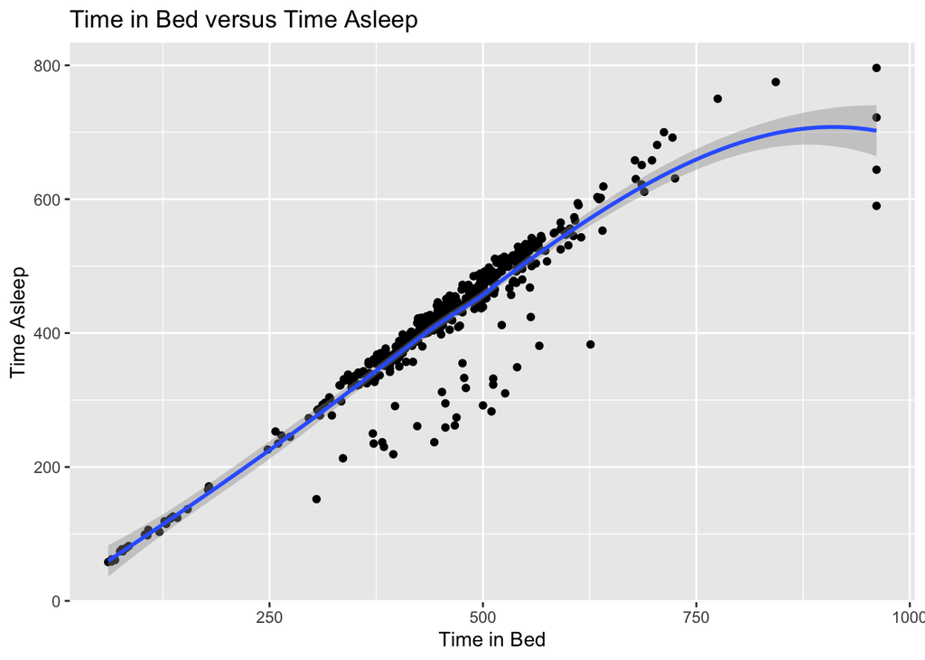

```r
ggplot(data = sleep, aes(x = TotalTimeInBed, y = TotalMinutesAsleep)) + geom_point() + geom_smooth() + labs(title = "Time in Bed versus Time Asleep", x = "Time in Bed", y = "Time Asleep")
```

The plot above illustrates a correlation between time in bed and minutes asleep that begins to plateau at about 700 minutes asleep or 875 minutes in bed. Thus, more time in bed doesn’t always correlate more minutes asleep.

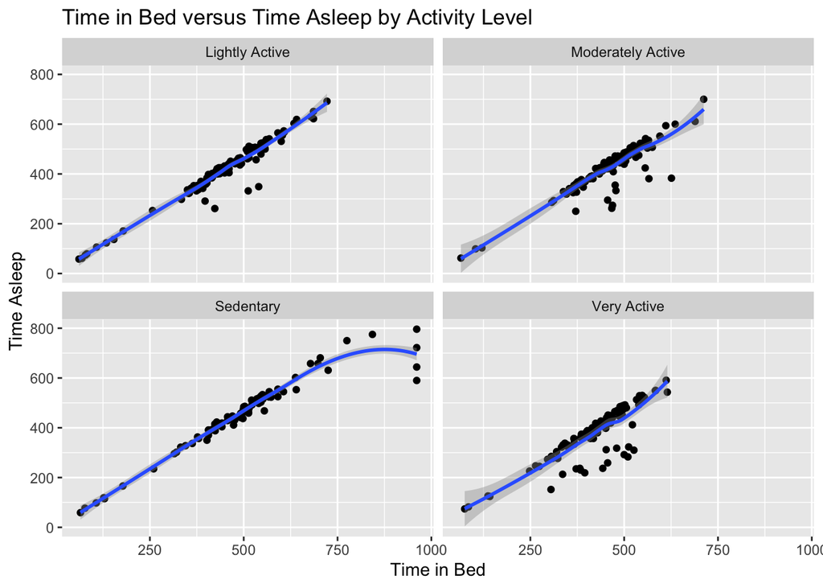

```r
ggplot(data = dailydata_sleepall, aes(x = TotalTimeInBed, y = TotalMinutesAsleep)) + geom_point() + geom_smooth() + facet_wrap(~DailyActivityLevel) + labs(title = "Time in Bed versus Time Asleep by Activity Level", x = "Time in Bed", y = "Time Asleep")
```

The graph above shows the time in bed versus time asleep per activity level. It illustrates that uses who had sedentary days experienced the plateau of the positive correlation between minutes asleep and time in bed. It even becomes a negative correlation once they have spent more than 875 minutes in bed. This means a portion of their extra sedentary time could be coming from their time in bed before or after sleeping.

In addition, the users’ sedentary days are the sole contributors to the plateau of the correlation in the overall graph. This can be seen by examining that the positive correlations between the two variables does not plateau for other activity levels.

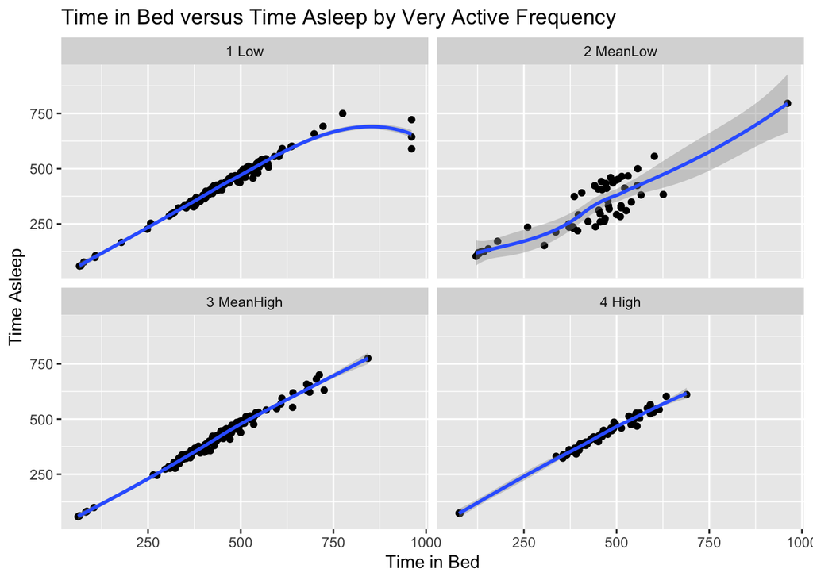

```r
ggplot(data = dailydata_sleepall, aes(x = TotalTimeInBed, y = TotalMinutesAsleep)) + facet_wrap(~VeryActiveStatus) + geom_point() + geom_smooth() + labs(title = "Time in Bed versus Time Asleep by Very Active Frequency", x = "Time in Bed", y = "Time Asleep")
```

The plot above illustrates a similar concept, except from the angle of frequency of time spent at a very active level. Indeed, users who spend a low amount of time as very active tend to see the positive correlation between time in bed and time asleep turn into a negative correlation.

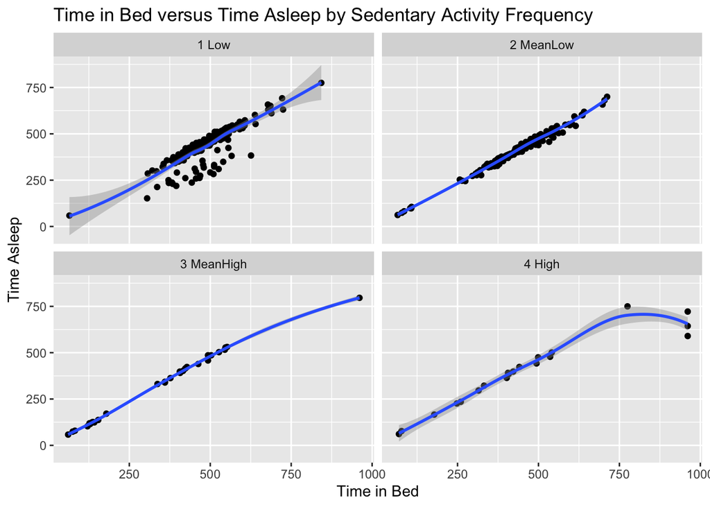

```r
ggplot(data = dailydata_sleepall, aes(x = TotalTimeInBed, y = TotalMinutesAsleep)) + facet_wrap(~SedentaryActiveStatus) + geom_point() + geom_smooth() + labs(title = "Time in Bed versus Time Asleep by Sedentary Activity Frequency", x = "Time in Bed", y = "Time Asleep")
```

This can be seen yet again in the plot above, where higher amounts of sedentary time result in a positive correlation between minutes asleep and time in bed that plateaus. In contrast, lower amounts of sedentary time do not see the same plateau.

##### Activity data

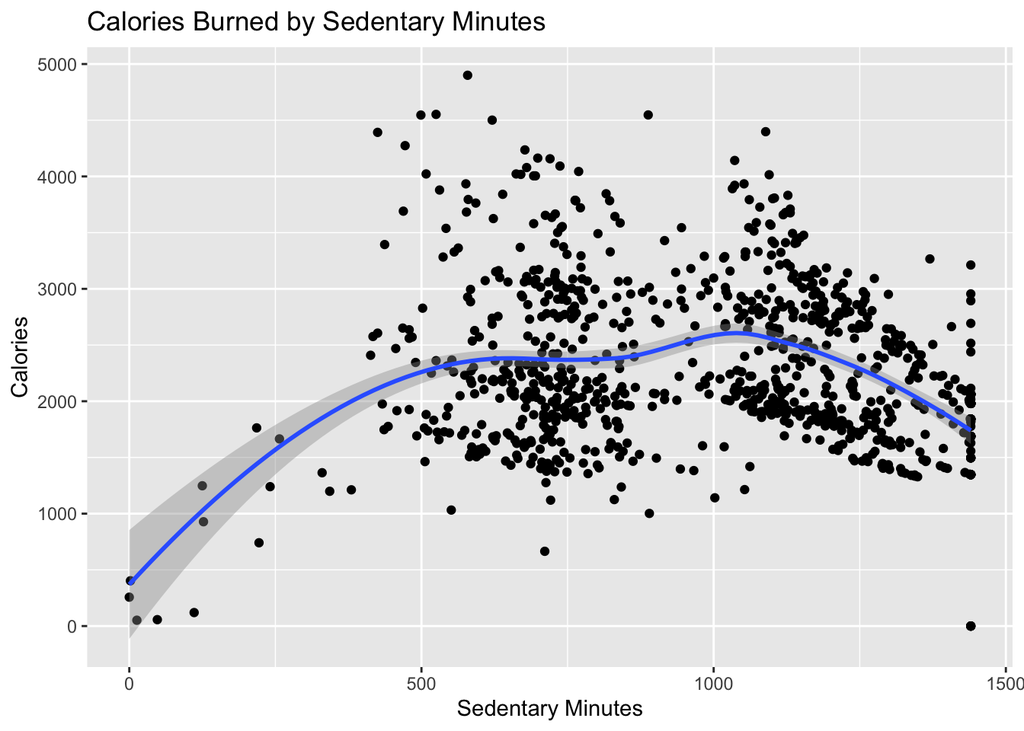

```r
ggplot(data = activity, aes(x = SedentaryActiveMinutes, y = Calories)) + geom_point() + geom_smooth() + labs(title = "Calories Burned by Sedentary Minutes", x = "Sedentary Minutes")
```

##### Daily data

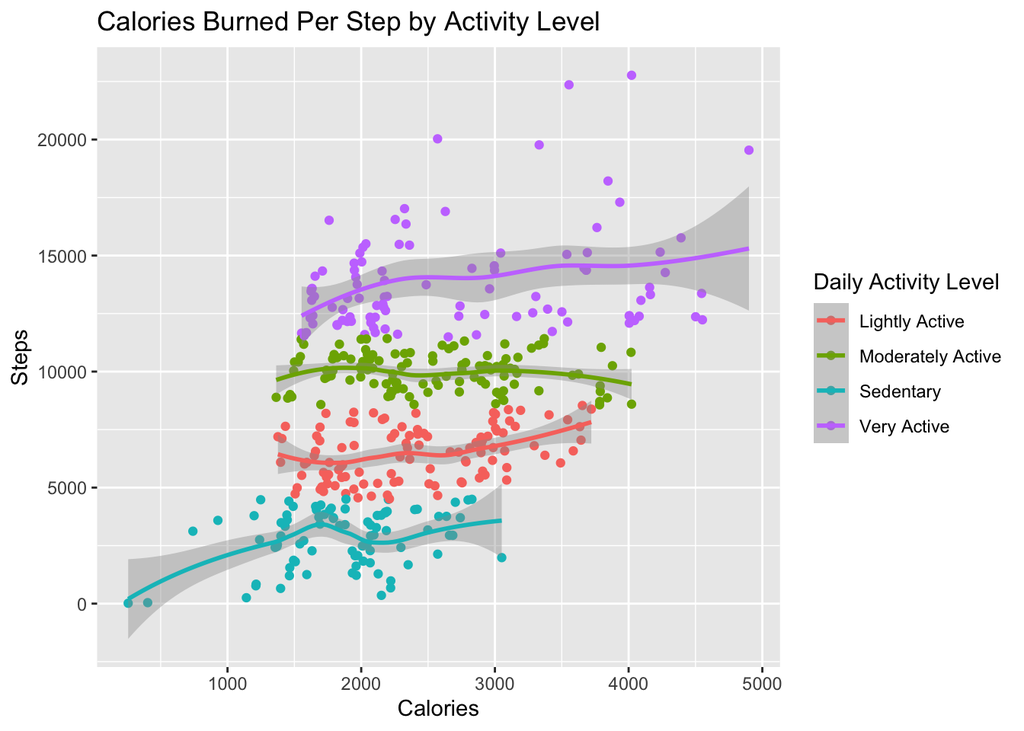

```r
ggplot(data = dailydata_sleepall, aes(x = Calories, y = TotalSteps, color = DailyActivityLevel)) + geom_point() + geom_smooth() + labs(title = "Calories Burned Per Step by Activity Level", y = "Steps", color = "Daily Activity Level")
```

Let’s also take a look at the daily data. The plot above illustrates that, as activity levels increase, users will take more steps and burn more calories. Sedentary days did not exceed roughly 3000 calories burned or 5000 steps taken, while very active days saw nearly 5000 calories burned and over 15000 steps taken.

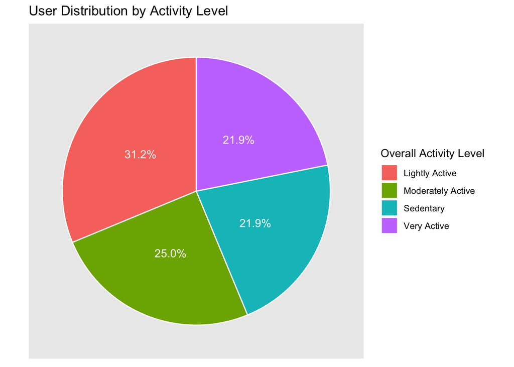

```r
user_activitylevel <- data.frame(table(DailyDataIdAvg$OverallActivityLevel))
colnames(user_activitylevel) <- c("OverallActivityLevel", "NumberofUsers")
user_activitylevel$Percentage <- c(10/32, 8/32, 7/32, 7/32)
user_activitylevel$Percentage <- sprintf("%0.1f%%", user_activitylevel$Percentage * 100)


ggplot(user_activitylevel, aes(x = "", y = NumberofUsers, fill = OverallActivityLevel)) +
  geom_bar(width = 1, stat = "identity", color = "white") +
  coord_polar("y", start = 0) +
  theme(axis.title.x= element_blank(),
        axis.title.y = element_blank(),
        panel.border = element_blank(),
        panel.grid = element_blank(),
        axis.ticks = element_blank(),
        axis.text.x = element_blank()) +
  geom_text(aes(label = Percentage), position = position_stack(vjust = 0.5), color = "white")+
  labs(title = "User Distribution by Activity Level", fill = "Overall Activity Level")
```

I also created a pie chart that shows the user distribution by overall activity level. Per the chart, users are distributed just about evenly across all activity levels, indicating that one user type is not necessarily more likely to wear a health tracking device than another. This means that there is just as much of an opportunity to reach sedentary users as any other user type in order to increase their activity level over time.

### Act

Another feature that could stem the excess time in bed, and thus sedentary time, would be a bedtime and wake up feature. This will allow users to set the time they would like to go to bed and wake up, with notifications that communicate to them the optimal moments for both so that excessive time is not spent in bed before or after sleeping. This would be beneficial to the heart health of Bellabeat’s female audience because “sedentary behavior guidelines in several industrialized countries and recommendations from the American Diabetes Association call for an overall reduction in sedentary time and for regular interruption of long sedentary bouts” (Bellettiere et al., 2019). In this way, users can be encouraged to break up those bouts of sedentary time that can increase the risk of CVD.

One final addition that Bellabeat’s app could incorporate is a set of factoids about health that align with that user’s activity level. This could include findings from peer-reviewed studies such as the one quoted in this case study to empower users with the knowledge of their health, thus aligning with Bellabeat’s mission. Giving users these important factoids can be even more encouragement to get up and move around, as they will understand the long-term affects of their behavior on their health and mortality. Bolstering their own data with outsider peer-reviewed studies regarding cardiovascular health can add further merit to their devices as healthcare-focused when updating Bellabeat’s marketing strategy.

As for next steps, Bellabeat should begin by doing research into peer-reviewed studies to examine other health benefits to physical activity and the detriment that sedentary activity does to one’s body. Then, they can incorporate this information into alerts on the users’ phones when they have been sedentary too long. Bellabeat can then finally update their marketing materials to reveal their new, more healthcare-focused and science-backed approach to the wearable fitness device space.

Additional data that can expand on my findings would be data from Bellabeat’s current products. It could be beneficial to examine the current user base for Bellabeat, alongside the FitBit data, for more plentiful, verifiable first-hand data. This way, other factors like age and gender can be examined to make further conclusions about the importance of these findings within the health of Bellabeat’s target audience of women.

### References

Bellettiere, J., LaMonte, M. J., Evenson, K. R., Rillamas-Sun, E., Kerr, J., Lee, I.-M., Di, C., Rosenberg, D. E., Stefanick, M. L., Buchner, D. M., Hovell, M. F., & LaCroix, A. Z. (2019). Sedentary behavior and cardiovascular disease in older women. Circulation, 139(8), 1036–1046. https://doi.org/10.1161/circulationaha.118.035312

Furberg, R., Brinton, J., Keating, M., & Ortiz, A. (2016, May 31). Crowd-sourced Fitbit datasets 03.12.2016-05.12.2016. Zenodo. Retrieved April 17, 2022, from https://zenodo.org/record/53894#.Ym2R9_PML6i